# Git and GitHub: Collaborative Usage

Dominic Bordelon, University Library System

## Agenda

1. GitHub Access Permissions
2. Forks: copies of a repository
3. Pull requests (PRs)
4. Merge conflicts: when branches collide
5. The blame feature
6. Repository management paradigms

## About the trainer

**Dominic Bordelon, Research Data Librarian**  
University Library System, University of Pittsburgh  
dbordelon@pitt.edu

Services for the Pitt community:

- Consultations
- Training (on-request and via public workshops)
- Talks (on-request and publicly)
- Research collaboration

Support areas and interests:

- Computer programming fundamentals, esp. for data processing and analysis
- Open Science and Data Sharing
- Data stewardship/curation
- Research methods; science and technology studies

## GitHub Access Permissions

Anyone can clone or pull from a *public* GH repo. (A repo may also be set to *private*.)

Only authorized Collaborators may *push* to a repo. To add Collaborators, click on your repo’s Settings button (top right), then Collaborators from the left menu.

💡 If your repo has multiple Contributors, consider having everyone work in their own branch, to minimize the number of merges needed as users push and pull to the `origin` repo.

# Forks: copies of a repository

## Forks

A **fork** is a copy of the repository under a new owner (usually retains original name). The fork owner can make whatever modifications they desire. So if I want to make a derivative project of tidyverse/dplyr, I can fork it to create dojobo/dplyr (dojobo is my username).

Parent repository updates can be merged into the fork at any time. So using the dplyr example, I can merge new tidyverse/dplyr commits into dojobo/dplyr, keeping up with the new developments.

To see what forks exist: Insights > Forks. (See also: Network)

To create your own fork: click Fork on the main page.

[figure not shown]

The Fork button, to make your own fork of a posted repo. Insights is also highlighted, where you may find the list of Forks and the Network graph (see next slide).

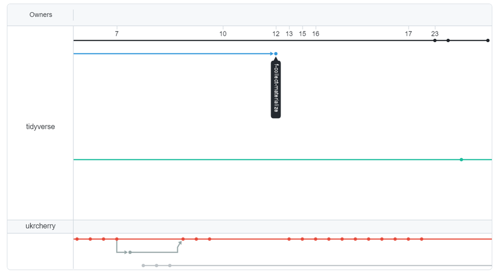

## Activity: Fork our repo

1. Go to our repo for this workshop (I will provide the URL).
2. Click on Fork at top right to fork it into your account. Read the default settings and leave them as-is. Click the Create fork button.
3. Examine the new repository you’ve created, and confirm that it is a fork.
4. Create a new branch and commit a new file (you may do this on the GH website, or on a local clone, which you then push).
5. Refresh your fork on GH and confirm that your commit is there.

# Pull Requests (PRs): collaborative merging

## Pull requests (PRs)

Once a collaborator has developed their branch sufficiently and wants it merged to `main`, they make a request to repo administrators. This is called a **pull request (PR)** because you are asking to have your branch’s commits *pulled* into `main`. (Not consistent with the `git pull` command!)

If the admin says Yes to the PR, the commits are merged into the target repo.

Depending on the nature of the commits, the repository’s contribution policies, and your relationship to the repo admins, you may need to make a case for your PR, or may even be outright rejected.

To make a PR, click Pull Requests (top middle) and click New pull request.

💡 A PR can occur across separate forks, or across branches within the same repository.

## Activity: Examine pull requests

1. On the tidyverse/dplyr repo, click on Pull requests.
2. Review some of the open PRs.
3. Click on the “Closed” button to see a list of Closed PRs, and review a few of those. Examine at least one accepted PR and one rejected PR.

## Activity: Create a Pull Request

You will ask to have the commit you created in a previous activity, merged into our repo for this workshop.

1. Go to the repo for this workshop.
2. Initiate a PR by clicking Pull Request and then New pull request.
3. On the Compare Changes screen, select the appropriate branches for merging. The workshop repo and branch should be on the left, and your fork and repo on the right.
4. Examine the diffs and create a PR.

Then I will accept the PRs.

# Merge conflicts: when branches collide

## Merge conflicts

When you merge Branch B into Branch A, git will attempt to auto-merge, i.e., automatically reconcile the two branches. An example of a straightforward auto-merge is a new file created in Branch A, and a modified existing file in Branch B: both changes take effect.

If the merge can’t be resolved automatically, then merging halts:

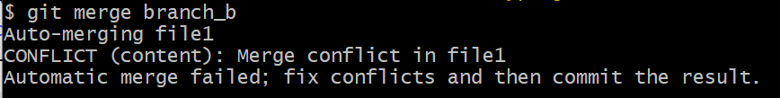

and a *merge conflict* is generated at each appropriate position in the files.

Here’s an example of what a merge conflict looks like:

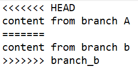

The `=======` is a divider between the contributions from each branch. (Note: `HEAD` is git’s term for your current position, or which commit you currently have checked out. In the merge situation, it corresponds to the most recent commit of Branch A.) You’ll have to manually reconcile the content in the “fenced” area, then delete the divider and fences.

Once all merge conflicts are resolved, you can stage and commit the changes, to complete the merge.

# The blame feature

## The blame feature

The **blame** feature, which is not really about “blaming,” tells you, for a given file, which user committed (wrote) each line. This can be useful when reconstructing history, bug-hunting, or re-assessing current design choices.

Similar to `log`, `blame` is available on the command-line, but probably best experienced in a richer platform like GitHub.

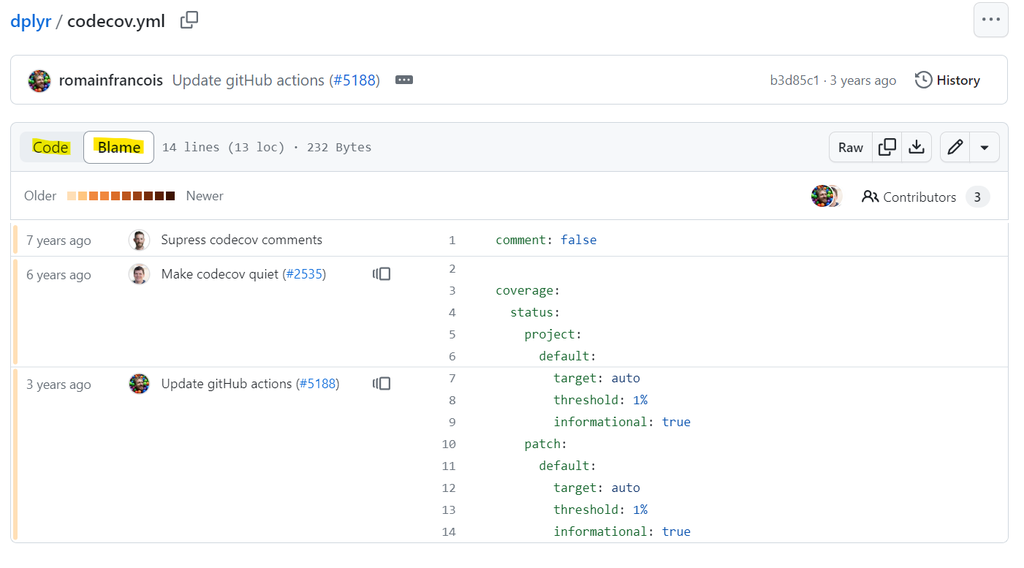

A file in the tidyverse/dplyr repo, codecov.yml. The view has been switched from Code (the default) to Blame. Note that each line in the file is assigned an author and commit.

# Repository management paradigms

## Branching workflows

- Long-running branches may be left open and merged across at various moments by an authority. This is called a [Gitflow](https://www.atlassian.com/git/tutorials/comparing-workflows/gitflow-workflow) style.
- `main` is usually the “stable” branch. `develop` is a parallel branch to test stability. Various topic branches “graduate” into `develop`, and changes in `develop` graduate into `main`.
- Topic branches may be many and small, to silo multiple working environments from one another. A team that focuses on merging small branches into a trunk frequently—contrasted with Gitflow’s long-running branches—is called [trunk-based development](https://www.atlassian.com/continuous-delivery/continuous-integration/trunk-based-development).
- A merged branch *may* be deleted, but not that doing so simplifies the repo history and prevents further development on the branch.

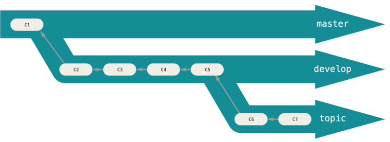

Progressive-stability branching; changes graduate from topics to `develop` and then to `main`. Image source: [Pro Git](https://git-scm.com/book/en/v2/Git-Branching-Branching-Workflows)

[figure not shown]

A Gitflow branching example. Source: [Atlassian, “Gitflow Workflow”](https://www.atlassian.com/git/tutorials/comparing-workflows/gitflow-workflow)

## Distributed management paradigms

- Centralized workflow
- Integration-manager workflow
- Dictator and lieutenants workflow
- Distributed workflows: https://git-scm.com/book/en/v2/Distributed-Git-Distributed-Workflows

## Centralized workflow

In a centralized workflow, everyone has push access. This is safe, but may require many merges when there are concurrent users.

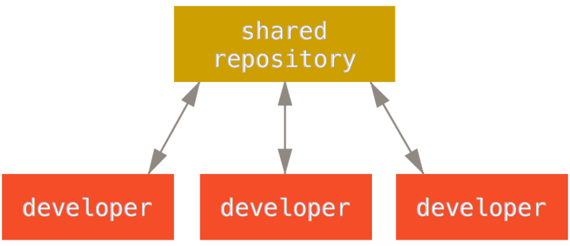

Centralized workflow. Source: [Pro Git](https://git-scm.com/book/en/v2/Distributed-Git-Distributed-Workflows)

## Integration-manager workflow

Individual developers work in isolation and then publish their forks publicly. The integration manager merges changes into the “blessed” repository from developers’ forks.

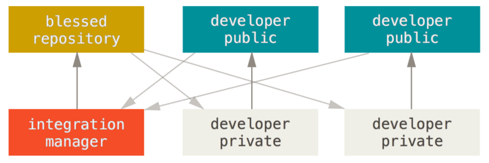

Integration-manager workflow. Source: [Pro Git](https://git-scm.com/book/en/v2/Distributed-Git-Distributed-Workflows)

## Dictator and lieutenants workflow

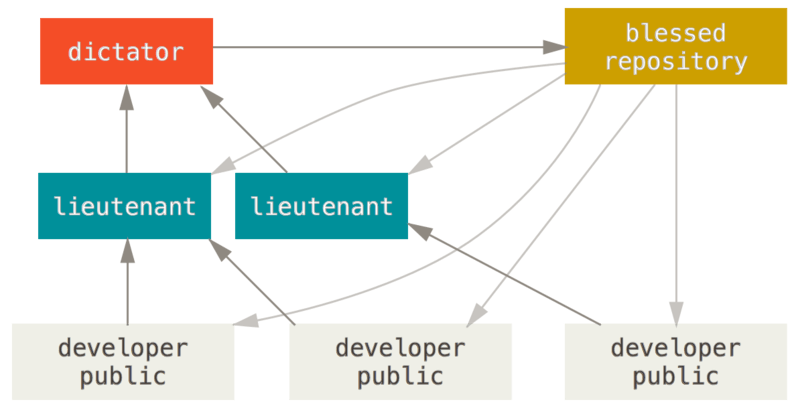

Dictator and lieutenants workflow. Source: [Pro Git](https://git-scm.com/book/en/v2/Distributed-Git-Distributed-Workflows)

## Resources for learning and practice

- Pro Git book, available online: https://git-scm.com/book/en/v2
- Git Gud, an in-browser git simulator: https://nic-hartley.github.io/git-gud/
- Learning resources collected by GitHub: https://docs.github.com/en/get-started/quickstart/git-and-github-learning-resources
- Cheat sheet for commands usable in Git Bash and macOS Terminal: https://github.com/RehanSaeed/Bash-Cheat-Sheet

Or you can look for git and GitHub integrations in software you already use, for example: [git in VS Code](https://code.visualstudio.com/docs/sourcecontrol/overview), [git in RStudio](https://code.visualstudio.com/docs/sourcecontrol/overview), [git in PyCharm](https://www.jetbrains.com/help/pycharm/set-up-a-git-repository.html)

Or you can delve into one of these topics:

- [GitHub Pages](https://pages.github.com/): easily build and host an associated page for your project (or create an empty repo solely to host a webpage)
- [GitHub Actions](https://github.com/features/actions): automate workflows, such as running a suite of tests on your code every time a new commit is pushed, to mitigate introduction of new bugs.

[figure not shown]

Git and GitHub: Collaborative Usage